# Hands-on Practice for Staggered Diff-in-Diff in R

- Show All Code
- Hide All Code
- View Source

Author

Heeyoung Lee

Published

November 12, 2025

# Introduction

This document compares modern difference-in-differences (DiD) estimators designed to handle staggered treatment adoption. Traditional two-way fixed effects (TWFE) estimators can produce biased estimates when treatment timing varies across units. The methods compared here address this issue through different approaches.

## Methods Overview

1. **Traditional TWFE**: Baseline (biased) estimator
2. **Callaway & Sant’Anna (2021)**: Group-time specific treatment effects
3. **Sun & Abraham (2021)**: Interaction-weighted estimator
4. **Wooldridge ETWFE (2021)**: Extended two-way fixed effects
5. **Gardner Two-Stage (2022)**: Two-stage difference-in-differences

# Setup

Load required packages for the analysis.

```r
library(tidyverse)
library(did)
library(fixest)
library(DIDmultiplegt)
library(did2s)
library(etwfe)
```

# 1. Data Generation

We simulate a balanced panel dataset with staggered treatment adoption. Treatment occurs at different times for different cohorts:

- Cohort 1 (units 1-25): treated at time 5
- Cohort 2 (units 26-50): treated at time 6
- Cohort 3 (units 51-75): treated at time 7
- Never-treated (units 76-100): never receive treatment

The data generating process features both **cohort heterogeneity** and **dynamic treatment effects**:

- **Cohort heterogeneity**: Treatment effects differ across groups based on when they adopt treatment. Early adopters (Cohort 1) experience larger baseline effects (6) than middle adopters (Cohort 2, effect = 3) or late adopters (Cohort 3, effect = 1).
- **Dynamic treatment effects**: Treatment effects grow over time after adoption. Each additional period of exposure increases the effect by 0.8 units. For example, a unit treated at time 5 experiences effects of 6.0 (at t=5), 6.8 (at t=6), 7.6 (at t=7), and so on.

The true average treatment effect on the treated (ATT) is approximately **5.36**. This represents the average effect across all treated units in all post-treatment periods, accounting for both the varying baseline effects by cohort and the accumulation of effects over time.

## Data Generating Process

The outcome variable is generated as:

$$y_{it} = 2 + 0.5 \times id_i + 0.3 \times time_t + TE_{it} \times treated_{it} + \epsilon_{it}$$

where:

- **Unit fixed effects**: $0.5 \times id_i$ (captures time-invariant unit characteristics)
- **Time fixed effects**: $0.3 \times time_t$ (captures common time trends)
- **Heterogeneous treatment effect**: $TE_{it} = \text{cohort\_effect}_g + 0.8 \times \text{time\_since\_treatment}_{it}$
  - Cohort 1 (early adopters): Base effect = 6
  - Cohort 2 (middle adopters): Base effect = 3
  - Cohort 3 (late adopters): Base effect = 1
  - Dynamic component: Effect grows by 0.8 for each period after treatment
- **Error term**: $\epsilon_{it} \sim N(0, 0.5^2)$

This design incorporates two key sources of treatment effect heterogeneity:

1. **Cohort heterogeneity**: Early adopters experience larger treatment effects than late adopters
2. **Dynamic effects**: Treatment effects accumulate over time, growing by 0.8 per period

The true ATT (5.36) is calculated as the weighted average of treatment effects across all treated unit-time observations.

## Why This Matters for TWFE

Under staggered adoption with heterogeneous treatment effects, traditional TWFE estimators use problematic comparisons:

1. **Earlier-treated vs later-treated units**: Later-treated units serve as controls for earlier-treated units, but they eventually get treated themselves
2. **Later-treated vs earlier-treated units**: Already-treated units serve as “controls” for newly treated units, creating negative weights. This is particularly problematic when early adopters have larger treatment effects
3. **Treatment effect heterogeneity**: TWFE produces a weighted average that assigns negative weights to some treatment effects, potentially yielding estimates that do not represent any meaningful causal parameter

In this simulation, TWFE is expected to produce substantially biased estimates because:

- Early-treated units (large effects) are used as controls for later-treated units (small effects)
- Units with longer exposure (larger cumulative effects) are compared with newly treated units
- The combination of cohort and dynamic heterogeneity maximizes the bias from forbidden comparisons

Modern DiD estimators (Callaway & Sant’Anna, Sun & Abraham, etc.) address these issues by:

- Using only clean comparison groups (never-treated or not-yet-treated)
- Avoiding forbidden comparisons between differentially-treated units
- Explicitly modeling treatment effect heterogeneity across cohorts and time

```r
set.seed(123)
n_units <- 100
n_periods <- 10

data <- expand.grid(id = 1:n_units, time = 1:n_periods) %>%
  mutate(
    treat_time = case_when(
      id <= 25 ~ 5,
      id <= 50 ~ 6,
      id <= 75 ~ 7,
      TRUE ~ 0
    ),
    treated = if_else(treat_time > 0 & time >= treat_time, 1, 0),
    # Both cohort AND dynamic heterogeneity
    cohort_effect = case_when(
      treat_time == 5 ~ 6,
      treat_time == 6 ~ 3,
      treat_time == 7 ~ 1,
      TRUE ~ 0
    ),
    time_since_treatment = if_else(treated == 1, time - treat_time, 0),
    dynamic_effect = 0.8 * time_since_treatment,
    true_te = cohort_effect + dynamic_effect,
    y = 2 + 0.5*id + 0.3*time + true_te*treated + rnorm(n(), sd = 0.5)
  )

glimpse(data)
```

```
Rows: 1,000
Columns: 9
$ id                   <int> 1, 2, 3, 4, 5, 6, 7, 8, 9, 10, 11, 12, 13, 14, 15…
$ time                 <int> 1, 1, 1, 1, 1, 1, 1, 1, 1, 1, 1, 1, 1, 1, 1, 1, 1…
$ treat_time           <dbl> 5, 5, 5, 5, 5, 5, 5, 5, 5, 5, 5, 5, 5, 5, 5, 5, 5…
$ treated              <dbl> 0, 0, 0, 0, 0, 0, 0, 0, 0, 0, 0, 0, 0, 0, 0, 0, 0…
$ cohort_effect        <dbl> 6, 6, 6, 6, 6, 6, 6, 6, 6, 6, 6, 6, 6, 6, 6, 6, 6…
$ time_since_treatment <dbl> 0, 0, 0, 0, 0, 0, 0, 0, 0, 0, 0, 0, 0, 0, 0, 0, 0…
$ dynamic_effect       <dbl> 0, 0, 0, 0, 0, 0, 0, 0, 0, 0, 0, 0, 0, 0, 0, 0, 0…
$ true_te              <dbl> 6, 6, 6, 6, 6, 6, 6, 6, 6, 6, 6, 6, 6, 6, 6, 6, 6…
$ y                    <dbl> 2.519762, 3.184911, 4.579354, 4.335254, 4.864644,…
```

## Visualization

The heatmap below shows the treatment rollout pattern across units and time periods.

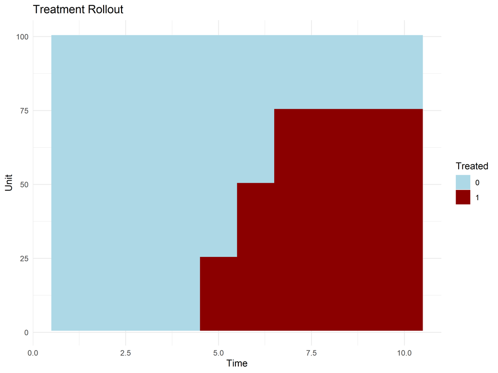

```r
ggplot(data, aes(x = time, y = id, fill = factor(treated))) +
  geom_tile() +
  scale_fill_manual(values = c("0" = "lightblue", "1" = "darkred")) +
  labs(title = "Treatment Rollout", x = "Time", y = "Unit", fill = "Treated") +
  theme_minimal()
```

# 2. Traditional TWFE (Baseline)

Before examining modern DiD estimators, we first estimate the traditional two-way fixed effects (TWFE) model. This serves as our baseline for comparison and demonstrates the bias that arises under staggered treatment adoption with heterogeneous treatment effects.

## TWFE Estimation

The traditional TWFE specification regresses the outcome on a treatment indicator while controlling for unit and time fixed effects:

$$y_{it} = \alpha_i + \lambda_t + \beta \times treated_{it} + \epsilon_{it}$$

where $\alpha_i$ are unit fixed effects, $\lambda_t$ are time fixed effects, and $\beta$ is the estimated treatment effect.

```r
twfe <- feols(y ~ treated | id + time, data = data, cluster = ~id)
summary(twfe)
```

```
OLS estimation, Dep. Var.: y
Observations: 1,000
Fixed-effects: id: 100,  time: 10
Standard-errors: Clustered (id)
        Estimate Std. Error t value  Pr(>|t|)
treated  4.36095   0.241941 18.0248 < 2.2e-16 ***
---
Signif. codes:  0 '***' 0.001 '**' 0.01 '*' 0.05 '.' 0.1 ' ' 1
RMSE: 1.24135     Adj. R2: 0.989978
                Within R2: 0.452158
```

## TWFE Results

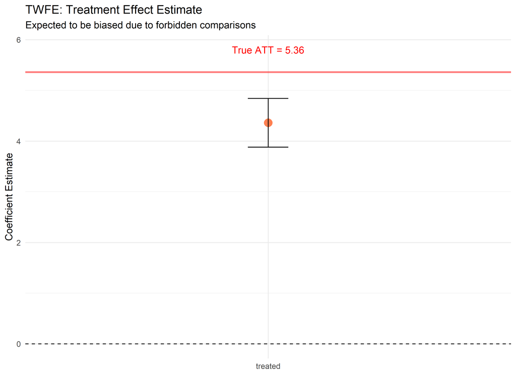

```r
twfe_coef <- broom::tidy(twfe, conf.int = TRUE)

ggplot(twfe_coef, aes(x = term, y = estimate)) +
  geom_point(size = 4, color = "coral") +
  geom_errorbar(aes(ymin = conf.low, ymax = conf.high), width = 0.1) +
  geom_hline(yintercept = 5.36, linetype = "solid", color = "red", alpha = 0.5, linewidth = 1) +
  geom_hline(yintercept = 0, linetype = "dashed", color = "black") +
  annotate("text", x = 1, y = 5.8, label = "True ATT = 5.36", color = "red", hjust = 0.5) +
  labs(title = "TWFE: Treatment Effect Estimate",
       subtitle = "Expected to be biased due to forbidden comparisons",
       x = "", y = "Coefficient Estimate") +
  theme_minimal()
```

```r
cat("\nTWFE Estimate:", round(coef(twfe)[1], 3),
    "\nTrue ATT:", 5.36,
    "\nBias:", round(coef(twfe)[1] - 5.36, 3))
```

```
TWFE Estimate: 4.361
True ATT: 5.36
Bias: -0.999
```

## TWFE Event Study

To further illustrate the bias in TWFE, we estimate an event study specification that allows treatment effects to vary by relative time to treatment adoption.

```r
# Create relative time variable
data_es <- data %>%
  mutate(
    rel_time = if_else(treat_time > 0, time - treat_time, Inf)  # Use Inf for never-treated
  )

# TWFE event study with relative time dummies
# Omit rel_time = -1 as reference period
twfe_es <- feols(y ~ i(rel_time, ref = c(-1, Inf)) | id + time,
                 data = data_es,
                 cluster = ~id)

summary(twfe_es)
```

```
OLS estimation, Dep. Var.: y
Observations: 1,000
Fixed-effects: id: 100,  time: 10
Standard-errors: Clustered (id)
              Estimate Std. Error  t value   Pr(>|t|)
rel_time::-6  2.987891   0.335070  8.91723 2.5075e-14 ***
rel_time::-5  2.450309   0.293432  8.35052 4.2342e-13 ***
rel_time::-4  1.407517   0.232855  6.04460 2.6532e-08 ***
rel_time::-3  0.938099   0.159911  5.86638 5.9163e-08 ***
rel_time::-2  0.444497   0.102993  4.31581 3.7734e-05 ***
rel_time::0   3.440511   0.171452 20.06694  < 2.2e-16 ***
rel_time::1   4.582172   0.191624 23.91231  < 2.2e-16 ***
rel_time::2   6.014615   0.240910 24.96624  < 2.2e-16 ***
rel_time::3   7.125742   0.286182 24.89936  < 2.2e-16 ***
rel_time::4   8.886144   0.318281 27.91916  < 2.2e-16 ***
rel_time::5  10.808232   0.336462 32.12319  < 2.2e-16 ***
---
Signif. codes:  0 '***' 0.001 '**' 0.01 '*' 0.05 '.' 0.1 ' ' 1
RMSE: 0.790775     Adj. R2: 0.995887
                 Within R2: 0.777684
```

## TWFE Event Study Plot

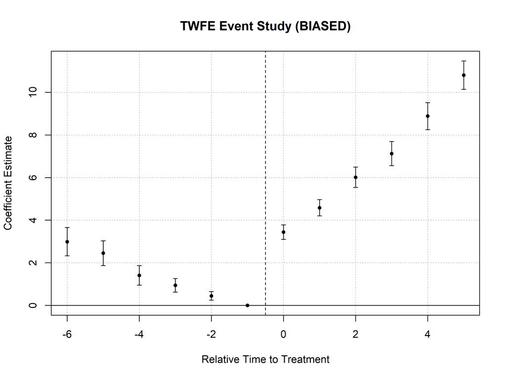

```r
# Plot event study
iplot(twfe_es,
      main = "TWFE Event Study (BIASED)",
      xlab = "Relative Time to Treatment",
      ylab = "Coefficient Estimate",
      ref.line = -0.5)
```

## Interpretation

The TWFE event study reveals several issues:

1. **Pre-treatment trends**: Ideally, coefficients for periods before treatment (rel_time < 0) should be close to zero, indicating parallel trends. Any significant pre-treatment coefficients suggest violations of the parallel trends assumption or specification issues.
2. **Post-treatment pattern**: The post-treatment coefficients should reflect the true dynamic treatment effects. However, under heterogeneous treatment effects, TWFE estimates are biased and do not accurately capture the true effect trajectory.

## Why is TWFE Biased?

**Reference**: [Goodman-Bacon (2021)](https://doi.org/10.1016/j.jeconom.2021.03.014)

In this setting, TWFE produces biased estimates because it implicitly uses already-treated units as controls for newly treated units. Specifically:

1. **Negative weights problem**: When comparing newly treated units (with small baseline effects) to already-treated units (with large cumulative effects), TWFE assigns negative weights to some comparisons.
2. **Forbidden comparisons**: Early-treated Cohort 1 units (experiencing effects of 6-10) serve as “controls” when Cohort 2 and 3 units receive treatment. This creates downward bias because the “control” group is actually experiencing large positive treatment effects.
3. **Dynamic effects ignored**: Units with longer exposure have accumulated larger effects, but TWFE treats all treated observations as having the same effect, leading to mis-specified comparisons.

# 3. Modern DiD Estimators

The modern DiD estimators presented below address the limitations of TWFE by using only clean comparison groups and explicitly accounting for treatment effect heterogeneity.

# 3-1. Method 1: Callaway & Sant’Anna (2021)

**Reference**:

- [did package vignette](https://cran.r-project.org/web/packages/did/vignettes/did-basics.html)
- [Callaway & Sant’Anna (2021)](https://doi.org/10.1016/j.jeconom.2020.12.001)

The Callaway & Sant’Anna approach estimates group-time specific average treatment effects and provides several aggregation options. It allows for flexible control group specifications (never-treated or not-yet-treated).

### Estimate Group-Time ATTs

```r
cs <- att_gt(yname = "y",
             tname = "time",
             idname = "id",
             gname = "treat_time",
             data = data,
             panel = TRUE,
             control_group = "nevertreated") # or "notyettreated"
summary(cs)
```

```
Call:
att_gt(yname = "y", tname = "time", idname = "id", gname = "treat_time",
    data = data, panel = TRUE, control_group = "nevertreated")

Reference: Callaway, Brantly and Pedro H.C. Sant'Anna.  "Difference-in-Differences with Multiple Time Periods." Journal of Econometrics, Vol. 225, No. 2, pp. 200-230, 2021. <https://doi.org/10.1016/j.jeconom.2020.12.001>, <https://arxiv.org/abs/1803.09015>

Group-Time Average Treatment Effects:
 Group Time ATT(g,t) Std. Error [95% Simult.  Conf. Band]
     5    2   0.0884     0.1635       -0.3926      0.5694
     5    3  -0.0398     0.1662       -0.5287      0.4492
     5    4   0.2224     0.2138       -0.4063      0.8511
     5    5   5.7155     0.1898        5.1573      6.2736 *
     5    6   6.6835     0.2109        6.0631      7.3039 *
     5    7   7.5391     0.2196        6.8933      8.1849 *
     5    8   8.2619     0.1696        7.7631      8.7608 *
     5    9   8.9779     0.2176        8.3379      9.6179 *
     5   10  10.0030     0.1827        9.4655     10.5405 *
     6    2   0.0435     0.1883       -0.5102      0.5973
     6    3  -0.1787     0.1815       -0.7125      0.3551
     6    4   0.3615     0.1927       -0.2051      0.9282
     6    5  -0.3135     0.1987       -0.8978      0.2708
     6    6   3.3812     0.1904        2.8212      3.9411 *
     6    7   4.1212     0.2245        3.4608      4.7817 *
     6    8   5.0590     0.2202        4.4112      5.7067 *
     6    9   5.4489     0.2141        4.8190      6.0788 *
     6   10   6.3846     0.1907        5.8238      6.9454 *
     7    2   0.3126     0.1862       -0.2352      0.8604
     7    3  -0.2532     0.1775       -0.7753      0.2690
     7    4   0.2494     0.2153       -0.3838      0.8826
     7    5  -0.1785     0.2077       -0.7893      0.4322
     7    6   0.0679     0.1488       -0.3696      0.5054
     7    7   1.1604     0.2039        0.5608      1.7600 *
     7    8   1.7816     0.1906        1.2211      2.3421 *
     7    9   2.5002     0.1914        1.9371      3.0633 *
     7   10   3.2225     0.2138        2.5936      3.8513 *
---
Signif. codes: `*' confidence band does not cover 0

P-value for pre-test of parallel trends assumption:  0.75998
Control Group:  Never Treated,  Anticipation Periods:  0
Estimation Method:  Doubly Robust
```

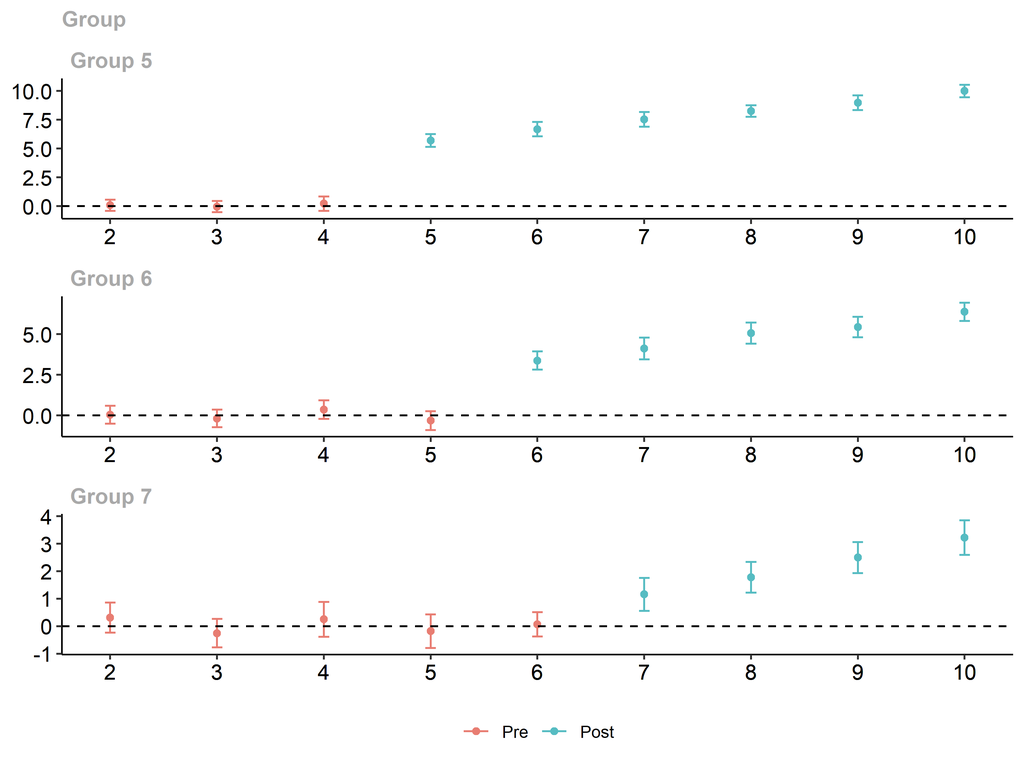

```r
ggdid(cs)
```

### Simple Aggregation

Overall average treatment effect on the treated (ATT).

```r
cs_simple <- aggte(cs, type = "simple")
summary(cs_simple)
```

```
Call:
aggte(MP = cs, type = "simple")

Reference: Callaway, Brantly and Pedro H.C. Sant'Anna.  "Difference-in-Differences with Multiple Time Periods." Journal of Econometrics, Vol. 225, No. 2, pp. 200-230, 2021. <https://doi.org/10.1016/j.jeconom.2020.12.001>, <https://arxiv.org/abs/1803.09015>

    ATT    Std. Error     [ 95%  Conf. Int.]
 5.3494        0.2795     4.8015      5.8972 *


---
Signif. codes: `*' confidence band does not cover 0

Control Group:  Never Treated,  Anticipation Periods:  0
Estimation Method:  Doubly Robust
```

### Event Study

Dynamic effects by relative time to treatment.

```r
cs_event <- aggte(cs, type = "dynamic")
summary(cs_event)
```

```
Call:
aggte(MP = cs, type = "dynamic")

Reference: Callaway, Brantly and Pedro H.C. Sant'Anna.  "Difference-in-Differences with Multiple Time Periods." Journal of Econometrics, Vol. 225, No. 2, pp. 200-230, 2021. <https://doi.org/10.1016/j.jeconom.2020.12.001>, <https://arxiv.org/abs/1803.09015>


Overall summary of ATT's based on event-study/dynamic aggregation:
   ATT    Std. Error     [ 95%  Conf. Int.]
 5.996        0.1943     5.6152      6.3768 *


Dynamic Effects:
 Event time Estimate Std. Error [95% Simult.  Conf. Band]
         -5   0.3126     0.1905       -0.1944      0.8196
         -4  -0.1048     0.1158       -0.4130      0.2034
         -3   0.0530     0.0900       -0.1866      0.2927
         -2   0.0477     0.0925       -0.1986      0.2941
         -1  -0.0077     0.0913       -0.2509      0.2354
          0   3.4190     0.2395        2.7816      4.0564 *
          1   4.1954     0.2594        3.5050      4.8859 *
          2   5.0328     0.2509        4.3649      5.7006 *
          3   5.6444     0.2448        4.9928      6.2960 *
          4   7.6813     0.2376        7.0488      8.3138 *
          5  10.0030     0.1833        9.5151     10.4909 *
---
Signif. codes: `*' confidence band does not cover 0

Control Group:  Never Treated,  Anticipation Periods:  0
Estimation Method:  Doubly Robust
```

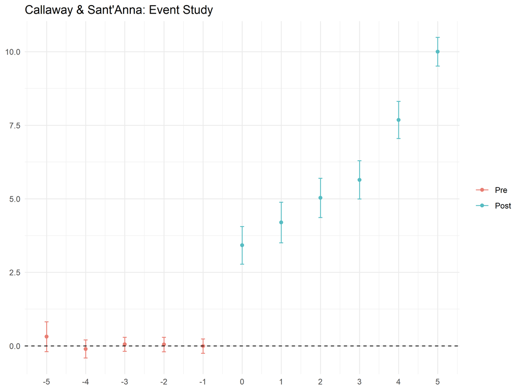

```r
ggdid(cs_event) +
  ggtitle("Callaway & Sant'Anna: Event Study") +
  theme_minimal()
```

### Group-Specific ATTs

Treatment effects by treatment cohort.

```r
cs_group <- aggte(cs, type = "group")
summary(cs_group)
```

```
Call:
aggte(MP = cs, type = "group")

Reference: Callaway, Brantly and Pedro H.C. Sant'Anna.  "Difference-in-Differences with Multiple Time Periods." Journal of Econometrics, Vol. 225, No. 2, pp. 200-230, 2021. <https://doi.org/10.1016/j.jeconom.2020.12.001>, <https://arxiv.org/abs/1803.09015>


Overall summary of ATT's based on group/cohort aggregation:
    ATT    Std. Error     [ 95%  Conf. Int.]
 4.9695        0.0901      4.793      5.1461 *


Group Effects:
 Group Estimate Std. Error [95% Simult.  Conf. Band]
     5   7.8635     0.1571        7.5029      8.2241 *
     6   4.8790     0.1532        4.5273      5.2307 *
     7   2.1662     0.1519        1.8175      2.5149 *
---
Signif. codes: `*' confidence band does not cover 0

Control Group:  Never Treated,  Anticipation Periods:  0
Estimation Method:  Doubly Robust
```

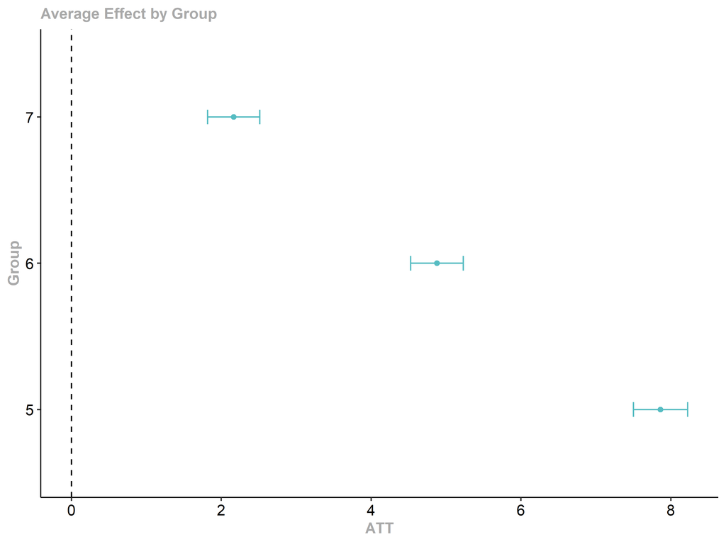

```r
ggdid(cs_group)
```

### Calendar Time Effects

Treatment effects by calendar time period.

```r
cs_ct <- aggte(cs, type = "calendar")
summary(cs_ct)
```

```
Call:
aggte(MP = cs, type = "calendar")

Reference: Callaway, Brantly and Pedro H.C. Sant'Anna.  "Difference-in-Differences with Multiple Time Periods." Journal of Econometrics, Vol. 225, No. 2, pp. 200-230, 2021. <https://doi.org/10.1016/j.jeconom.2020.12.001>, <https://arxiv.org/abs/1803.09015>


Overall summary of ATT's based on calendar time aggregation:
    ATT    Std. Error     [ 95%  Conf. Int.]
 5.3724        0.2512     4.8801      5.8648 *


Time Effects:
 Time Estimate Std. Error [95% Simult.  Conf. Band]
    5   5.7155     0.1930        5.2546      6.1764 *
    6   5.0323     0.2788        4.3668      5.6979 *
    7   4.2736     0.3360        3.4713      5.0758 *
    8   5.0342     0.3379        4.2273      5.8410 *
    9   5.6423     0.3420        4.8257      6.4590 *
   10   6.5367     0.3347        5.7376      7.3358 *
---
Signif. codes: `*' confidence band does not cover 0

Control Group:  Never Treated,  Anticipation Periods:  0
Estimation Method:  Doubly Robust
```

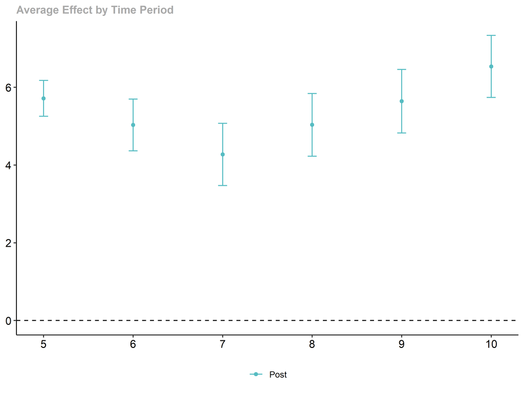

```r
ggdid(cs_ct)
```

# 3-2. Method 2: Sun & Abraham (2021)

**Reference**:

- [fixest](https://lrberge.github.io/fixest/reference/sunab.html)
- [Sun & Abraham](https://doi.org/10.1016/j.jeconom.2020.09.006)

### Estimate Model

```r
sa <- feols(y ~ sunab(treat_time, time) | id + time,
            data = data, cluster = ~id)
summary(sa)
```

```
OLS estimation, Dep. Var.: y
Observations: 1,000
Fixed-effects: id: 100,  time: 10
Standard-errors: Clustered (id)
          Estimate Std. Error   t value  Pr(>|t|)
time::-6 -0.198200   0.202140 -0.980507   0.32923
time::-5  0.100756   0.144329  0.698099   0.48675
time::-4 -0.093047   0.120974 -0.769152   0.44363
time::-3 -0.040019   0.103530 -0.386543   0.69992
time::-2  0.007721   0.090058  0.085733   0.93185
time::0   3.419003   0.091254 37.466841 < 2.2e-16 ***
time::1   4.195449   0.105981 39.586633 < 2.2e-16 ***
time::2   5.032767   0.116796 43.090156 < 2.2e-16 ***
time::3   5.644439   0.115382 48.919427 < 2.2e-16 ***
time::4   7.681256   0.149105 51.515880 < 2.2e-16 ***
time::5  10.002965   0.185820 53.831336 < 2.2e-16 ***
---
Signif. codes:  0 '***' 0.001 '**' 0.01 '*' 0.05 '.' 0.1 ' ' 1
RMSE: 0.464249     Adj. R2: 0.998556
                 Within R2: 0.923376
```

### Simple Aggregation

```r
sa_agg <- summary(sa, agg = "ATT")
print(sa_agg)
```

```
OLS estimation, Dep. Var.: y
Observations: 1,000
Fixed-effects: id: 100,  time: 10
Standard-errors: Clustered (id)
    Estimate Std. Error t value  Pr(>|t|)
ATT  5.34936   0.089256 59.9326 < 2.2e-16 ***
---
Signif. codes:  0 '***' 0.001 '**' 0.01 '*' 0.05 '.' 0.1 ' ' 1
RMSE: 0.464249     Adj. R2: 0.998556
                 Within R2: 0.923376
```

### Event Study

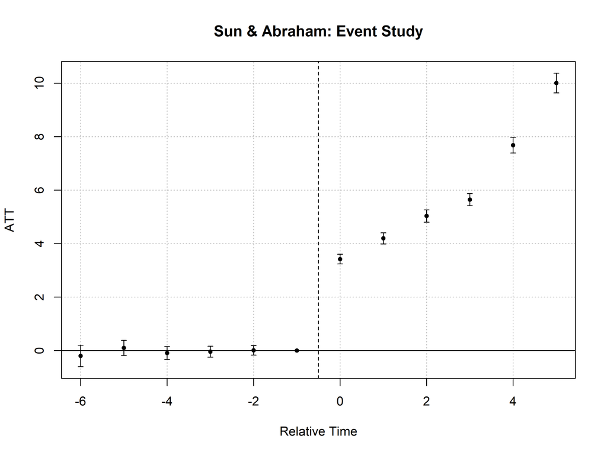

```r
iplot(sa, main = "Sun & Abraham: Event Study",
      ref.line = -0.5, xlab = "Relative Time", ylab = "ATT")
```

### Cohort-Specific Effects

```r
sa_cohort <- summary(sa, agg = "cohort")
print(sa_cohort)
```

```
OLS estimation, Dep. Var.: y
Observations: 1,000
Fixed-effects: id: 100,  time: 10
Standard-errors: Clustered (id)
          Estimate Std. Error t value  Pr(>|t|)
cohort::5  7.86348   0.155949 50.4236 < 2.2e-16 ***
cohort::6  4.87898   0.161864 30.1425 < 2.2e-16 ***
cohort::7  2.16617   0.155553 13.9256 < 2.2e-16 ***
---
Signif. codes:  0 '***' 0.001 '**' 0.01 '*' 0.05 '.' 0.1 ' ' 1
RMSE: 0.464249     Adj. R2: 0.998556
                 Within R2: 0.923376
```

# 3-3. Method 3: Wooldridge ETWFE (2023)

**Reference**:

- [etwfe package vignette](https://cran.r-project.org/web/packages/etwfe/vignettes/etwfe.html)
- [Wooldridge (2023)](https://doi.org/10.1093/ectj/utad016)

Wooldridge’s extended two-way fixed effects (ETWFE) approach saturates the model with all possible treatment-time interactions. Provides multiple aggregation options.

### Model 1: Not-Yet-Treated as Control

Default specification using not-yet-treated units as controls. Pre-treatment effects are mechanistically set to zero.

```r
etwfe_mod <- etwfe(fml = y ~ 1,
                   tvar = time,
                   gvar = treat_time,
                   data = data,
                   vcov = ~id)
summary(etwfe_mod)
```

```
OLS estimation, Dep. Var.: y
Observations: 1,000
Fixed-effects: treat_time: 4,  time: 10
Standard-errors: Clustered (id)
                               Estimate Std. Error  t value   Pr(>|t|)
.Dtreat:treat_time::5:time::5   5.93807   0.139961 42.42668  < 2.2e-16 ***
.Dtreat:treat_time::5:time::6   6.84527   0.117688 58.16471  < 2.2e-16 ***
.Dtreat:treat_time::5:time::7   7.71586   0.167109 46.17272  < 2.2e-16 ***
.Dtreat:treat_time::5:time::8   8.43869   0.133580 63.17316  < 2.2e-16 ***
.Dtreat:treat_time::5:time::9   9.15462   0.171331 53.43244  < 2.2e-16 ***
.Dtreat:treat_time::5:time::10 10.17971   0.150942 67.44110  < 2.2e-16 ***
.Dtreat:treat_time::6:time::6   3.26654   0.123135 26.52803  < 2.2e-16 ***
.Dtreat:treat_time::6:time::7   4.02159   0.149264 26.94280  < 2.2e-16 ***
.Dtreat:treat_time::6:time::8   4.95933   0.153305 32.34939  < 2.2e-16 ***
.Dtreat:treat_time::6:time::9   5.34926   0.159812 33.47229  < 2.2e-16 ***
.Dtreat:treat_time::6:time::10  6.28500   0.148343 42.36791  < 2.2e-16 ***
.Dtreat:treat_time::7:time::7   1.19034   0.153678  7.74570 8.3786e-12 ***
.Dtreat:treat_time::7:time::8   1.81157   0.141336 12.81747  < 2.2e-16 ***
.Dtreat:treat_time::7:time::9   2.53019   0.170112 14.87368  < 2.2e-16 ***
.Dtreat:treat_time::7:time::10  3.25244   0.148542 21.89577  < 2.2e-16 ***
... 12 variables were removed because of collinearity (.Dtreat:treat_time::5:time::2, .Dtreat:treat_time::5:time::3 and 10 others [full set in $collin.var])
---
Signif. codes:  0 '***' 0.001 '**' 0.01 '*' 0.05 '.' 0.1 ' ' 1
RMSE: 3.63672     Adj. R2: 0.921238
                Within R2: 0.164041
```

#### Simple Aggregation

```r
etwfe_agg <- emfx(etwfe_mod, type = "simple")
etwfe_agg
```

```
 .Dtreat Estimate Std. Error    z Pr(>|z|)   S 2.5 % 97.5 %
    TRUE      5.4      0.062 87.1   <0.001 Inf  5.27   5.52

Term: .Dtreat
Type:  response
Comparison: TRUE - FALSE
```

#### Event Study

```r
etwfe_es <- emfx(etwfe_mod, type = "event")
etwfe_es
```

```
 event Estimate Std. Error    z Pr(>|z|)   S 2.5 % 97.5 %
     0     3.46     0.0788 44.0   <0.001 Inf  3.31   3.62
     1     4.23     0.0822 51.4   <0.001 Inf  4.07   4.39
     2     5.07     0.0950 53.4   <0.001 Inf  4.88   5.25
     3     5.68     0.0940 60.4   <0.001 Inf  5.50   5.86
     4     7.72     0.1193 64.7   <0.001 Inf  7.49   7.95
     5    10.18     0.1509 67.4   <0.001 Inf  9.88  10.48

Term: .Dtreat
Type:  response
Comparison: TRUE - FALSE
```

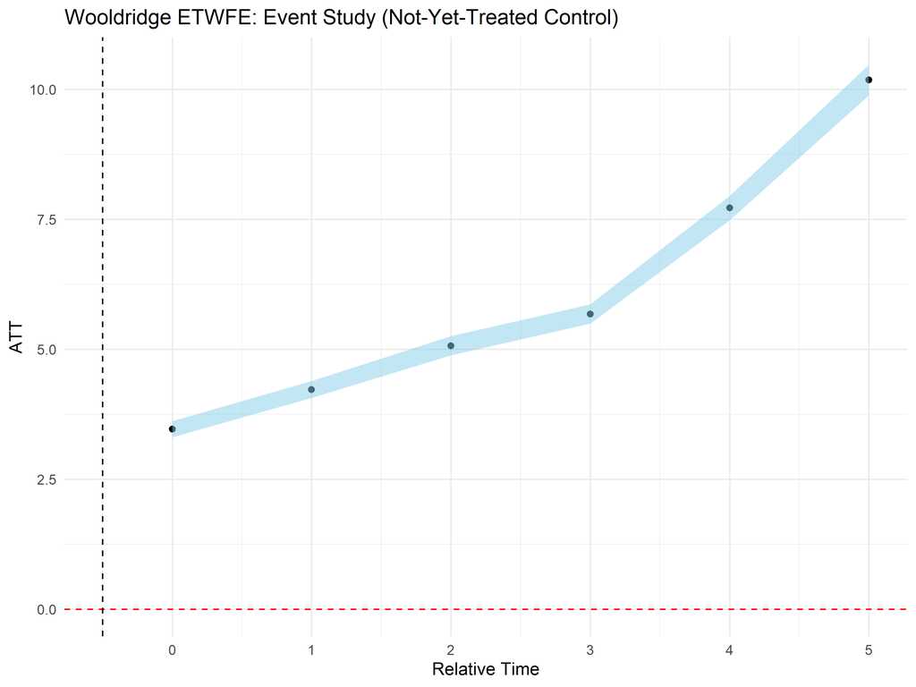

```r
ggplot(etwfe_es, aes(x = event, y = estimate)) +
  geom_point() +
  geom_ribbon(aes(ymin = conf.low, ymax = conf.high), fill = "skyblue", alpha = 0.5) +
  geom_hline(yintercept = 0, linetype = "dashed", color = "red") +
  geom_vline(xintercept = -0.5, linetype = "dashed") +
  labs(title = "Wooldridge ETWFE: Event Study (Not-Yet-Treated Control)",
       x = "Relative Time", y = "ATT") +
  theme_minimal()
```

**Note**: `emfx()` only reports post-treatment effects here because all pre-treatment effects are swept out under the “not-yet-treated” control group specification.

#### Cohort-Specific ATT

```r
etwfe_cohort <- emfx(etwfe_mod, type = "group")
etwfe_cohort
```

```
 treat_time Estimate Std. Error    z Pr(>|z|)     S 2.5 % 97.5 %
          5     8.05     0.0828 97.2   <0.001   Inf  7.88   8.21
          6     4.78     0.0730 65.4   <0.001   Inf  4.63   4.92
          7     2.20     0.0921 23.8   <0.001 414.9  2.02   2.38

Term: .Dtreat
Type:  response
Comparison: TRUE - FALSE
```

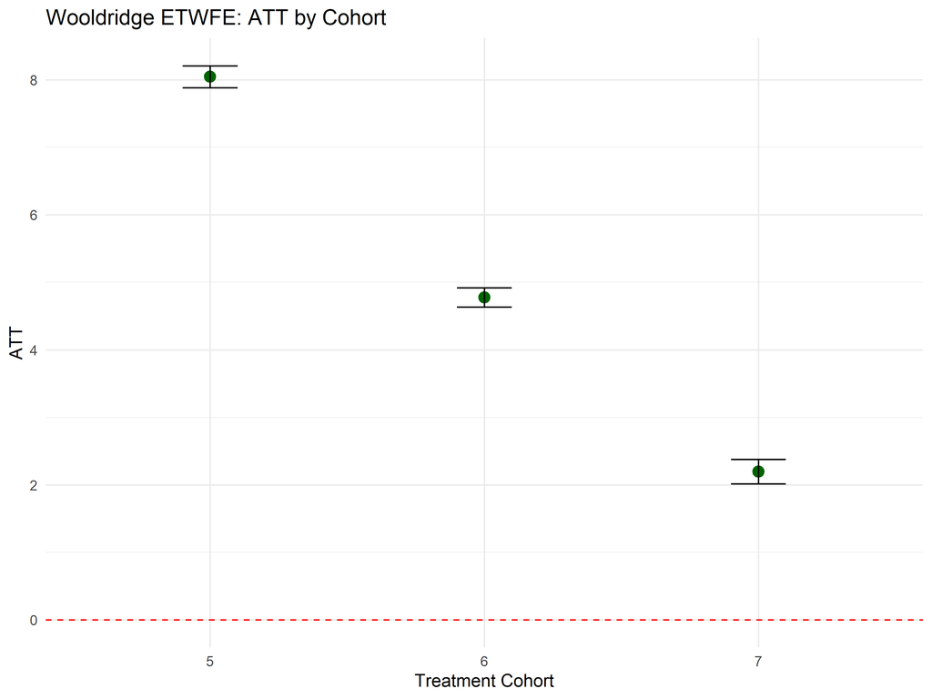

```r
ggplot(etwfe_cohort, aes(x = factor(treat_time), y = estimate)) +
  geom_point(size = 3, color = "darkgreen") +
  geom_errorbar(aes(ymin = conf.low, ymax = conf.high), width = 0.2) +
  geom_hline(yintercept = 0, linetype = "dashed", color = "red") +
  labs(title = "Wooldridge ETWFE: ATT by Cohort",
       x = "Treatment Cohort", y = "ATT") +
  theme_minimal()
```

#### Calendar Time Effects

```r
etwfe_calendar <- emfx(etwfe_mod, type = "calendar")
etwfe_calendar
```

```
 time Estimate Std. Error    z Pr(>|z|)     S 2.5 % 97.5 %
    5     5.94     0.1400 42.4   <0.001   Inf  5.66   6.21
    6     5.06     0.0998 50.6   <0.001   Inf  4.86   5.25
    7     4.31     0.1248 34.5   <0.001 865.0  4.06   4.55
    8     5.07     0.1139 44.5   <0.001   Inf  4.85   5.29
    9     5.68     0.1349 42.1   <0.001   Inf  5.41   5.94
   10     6.57     0.1215 54.1   <0.001   Inf  6.33   6.81

Term: .Dtreat
Type:  response
Comparison: TRUE - FALSE
```

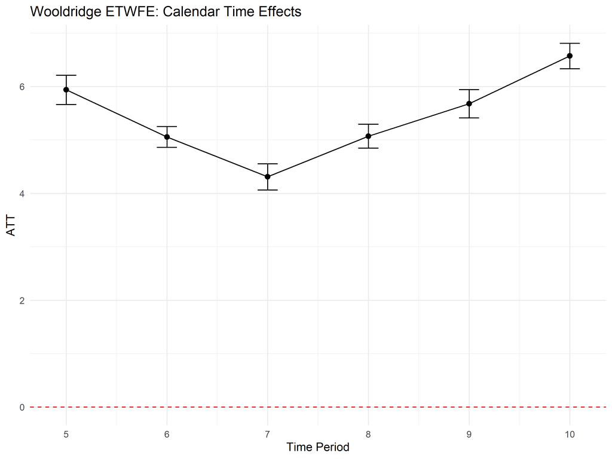

```r
ggplot(etwfe_calendar, aes(x = time, y = estimate)) +
  geom_point(size = 2) +
  geom_line() +
  geom_errorbar(aes(ymin = conf.low, ymax = conf.high), width = 0.2) +
  geom_hline(yintercept = 0, linetype = "dashed", color = "red") +
  labs(title = "Wooldridge ETWFE: Calendar Time Effects",
       x = "Time Period", y = "ATT") +
  theme_minimal()
```

### Model 2: Never-Treated as Control

Alternative specification using never-treated units as controls. This returns pre-treatment effects.

```r
etwfe_mod2 <- etwfe(fml = y ~ 1,
                    tvar = time,
                    gvar = treat_time,
                    data = data,
                    vcov = ~id,
                    cgroup = "never")
summary(etwfe_mod2)
```

```
OLS estimation, Dep. Var.: y
Observations: 1,000
Fixed-effects: treat_time: 4,  time: 10
Standard-errors: Clustered (id)
                                Estimate Std. Error   t value   Pr(>|t|)
.Dtreat:treat_time::5:time::1  -0.271027   0.186380 -1.454165 1.4906e-01
.Dtreat:treat_time::5:time::2  -0.182664   0.162190 -1.126238 2.6279e-01
.Dtreat:treat_time::5:time::3  -0.222415   0.208892 -1.064735 2.8959e-01
.Dtreat:treat_time::5:time::5   5.715474   0.188953 30.248058  < 2.2e-16 ***
.Dtreat:treat_time::5:time::6   6.683514   0.218579 30.577179  < 2.2e-16 ***
.Dtreat:treat_time::5:time::7   7.539111   0.216012 34.901334  < 2.2e-16 ***
.Dtreat:treat_time::5:time::8   8.261947   0.176748 46.744266  < 2.2e-16 ***
.Dtreat:treat_time::5:time::9   8.977871   0.224336 40.019747  < 2.2e-16 ***
.Dtreat:treat_time::5:time::10 10.002965   0.186111 53.747421  < 2.2e-16 ***
.Dtreat:treat_time::6:time::1   0.087109   0.201974  0.431286 6.6720e-01
.Dtreat:treat_time::6:time::2   0.130646   0.223690  0.584051 5.6051e-01
.Dtreat:treat_time::6:time::3  -0.048032   0.184315 -0.260595 7.9495e-01
.Dtreat:treat_time::6:time::4   0.313479   0.196901  1.592066 1.1456e-01
.Dtreat:treat_time::6:time::6   3.381160   0.185993 18.178992  < 2.2e-16 ***
.Dtreat:treat_time::6:time::7   4.121228   0.220165 18.718835  < 2.2e-16 ***
.Dtreat:treat_time::6:time::8   5.058972   0.221206 22.869941  < 2.2e-16 ***
.Dtreat:treat_time::6:time::9   5.448901   0.219611 24.811587  < 2.2e-16 ***
.Dtreat:treat_time::6:time::10  6.384641   0.199024 32.079702  < 2.2e-16 ***
.Dtreat:treat_time::7:time::1  -0.198200   0.202456 -0.978978 3.2998e-01
.Dtreat:treat_time::7:time::2   0.114403   0.188218  0.607823 5.4470e-01
.Dtreat:treat_time::7:time::3  -0.138762   0.190247 -0.729377 4.6749e-01
.Dtreat:treat_time::7:time::4   0.110639   0.212421  0.520849 6.0364e-01
.Dtreat:treat_time::7:time::5  -0.067901   0.151036 -0.449571 6.5400e-01
.Dtreat:treat_time::7:time::7   1.160374   0.211912  5.475742 3.3045e-07 ***
.Dtreat:treat_time::7:time::8   1.781603   0.191376  9.309416 3.5113e-15 ***
.Dtreat:treat_time::7:time::9   2.500218   0.186721 13.390112  < 2.2e-16 ***
.Dtreat:treat_time::7:time::10  3.222469   0.205184 15.705257  < 2.2e-16 ***
... 3 variables were removed because of collinearity (.Dtreat:treat_time::5:time::4, .Dtreat:treat_time::6:time::5 and .Dtreat:treat_time::7:time::6)
---
Signif. codes:  0 '***' 0.001 '**' 0.01 '*' 0.05 '.' 0.1 ' ' 1
RMSE: 3.63645     Adj. R2: 0.920265
                Within R2: 0.164164
```

#### Event Study with Pre-Treatment Effects

```r
etwfe_es2 <- emfx(etwfe_mod2, type = "event")
etwfe_es2
```

```
 event Estimate Std. Error       z Pr(>|z|)      S  2.5 % 97.5 %
    -6 -0.19820     0.2025 -0.9790    0.328    1.6 -0.595  0.199
    -5  0.10076     0.1446  0.6970    0.486    1.0 -0.183  0.384
    -4 -0.09305     0.1212 -0.7680    0.443    1.2 -0.331  0.144
    -3 -0.04002     0.1037 -0.3859    0.700    0.5 -0.243  0.163
    -2  0.00772     0.0902  0.0856    0.932    0.1 -0.169  0.185
    -1  0.00000         NA      NA       NA     NA     NA     NA
     0  3.41900     0.0914 37.4084   <0.001 1015.0  3.240  3.598
     1  4.19545     0.1061 39.5249   <0.001    Inf  3.987  4.403
     2  5.03277     0.1170 43.0230   <0.001    Inf  4.803  5.262
     3  5.64444     0.1156 48.8432   <0.001    Inf  5.418  5.871
     4  7.68126     0.1493 51.4356   <0.001    Inf  7.389  7.974
     5 10.00297     0.1861 53.7474   <0.001    Inf  9.638 10.368

Term: .Dtreat
Type:  response
Comparison: TRUE - FALSE
```

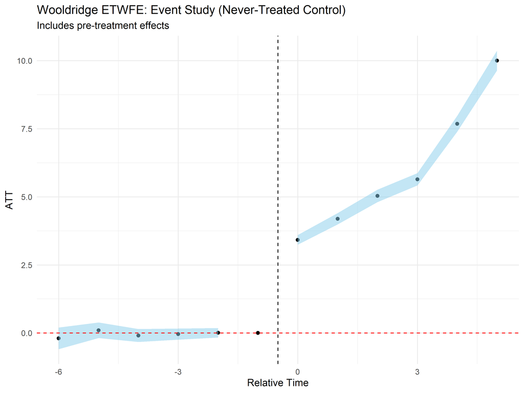

```r
ggplot(etwfe_es2, aes(x = event, y = estimate)) +
  geom_point() +
  geom_ribbon(aes(ymin = conf.low, ymax = conf.high), fill = "skyblue", alpha = 0.5) +
  geom_hline(yintercept = 0, linetype = "dashed", color = "red") +
  geom_vline(xintercept = -0.5, linetype = "dashed") +
  labs(title = "Wooldridge ETWFE: Event Study (Never-Treated Control)",
       subtitle = "Includes pre-treatment effects",
       x = "Relative Time", y = "ATT") +
  theme_minimal()
```

# 3-4. Method 4: Gardner Two-Stage (2022)

**Reference**:

- [did2s GitHub](https://github.com/kylebutts/did2s)
- [Gardner (2022)](https://doi.org/10.48550/arXiv.2207.05943)

Gardner’s two-stage approach first estimates unit and time fixed effects from untreated observations, then estimates treatment effects in the second stage.

### Simple Aggregation

```r
did2s_static <- did2s(
  data = data,
  yname = "y",
  first_stage = ~ 0 | id + time,
  second_stage = ~ i(treated, ref = FALSE),
  treatment = "treated",
  cluster_var = "id"
)

fixest::etable(did2s_static)
```

```
                     did2s_static
Dependent Var.:                 y

treated = 1     5.396*** (0.2821)
_______________ _________________
S.E. type                  Custom
Observations                1,000
R2                        0.70465
Adj. R2                   0.70465
---
Signif. codes: 0 '***' 0.001 '**' 0.01 '*' 0.05 '.' 0.1 ' ' 1
```

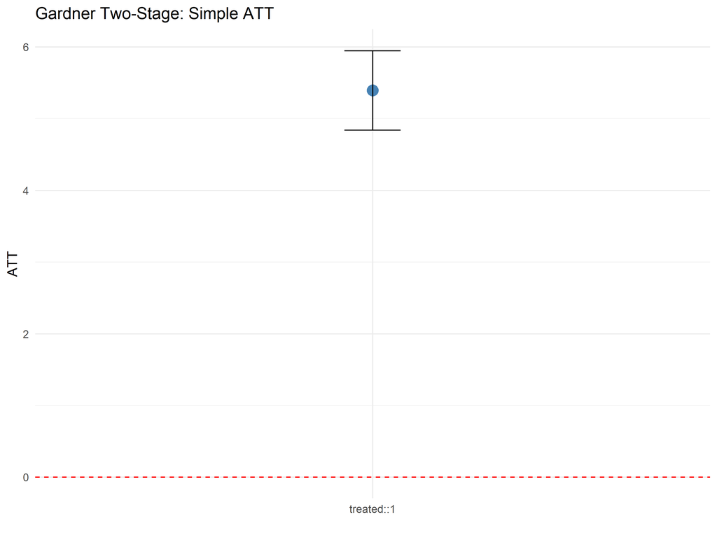

```r
coef_data <- broom::tidy(did2s_static, conf.int = TRUE)
ggplot(coef_data, aes(x = term, y = estimate)) +
  geom_point(size = 4, color = "steelblue") +
  geom_errorbar(aes(ymin = conf.low, ymax = conf.high), width = 0.1) +
  geom_hline(yintercept = 0, linetype = "dashed", color = "red") +
  labs(title = "Gardner Two-Stage: Simple ATT", x = "", y = "ATT") +
  theme_minimal()
```

### Event Study

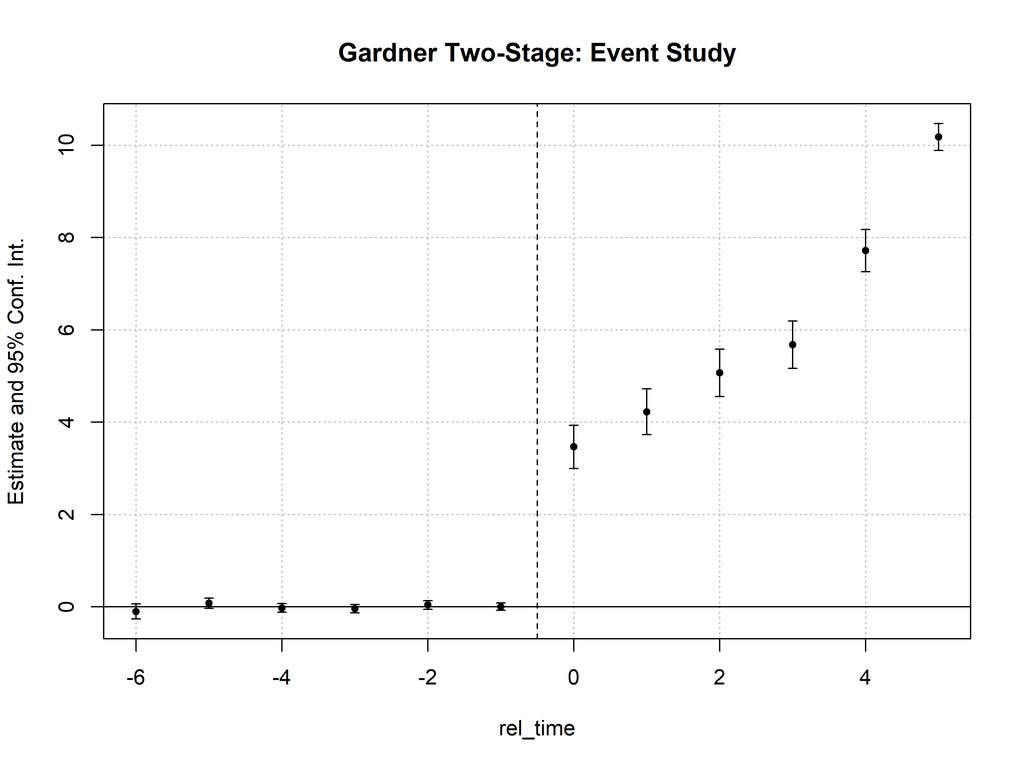

```r
data_es <- data %>%
  mutate(rel_time = if_else(treat_time > 0,
                            time - treat_time,
                            Inf)) # Inf for never treated

did2s_es <- did2s(
  data = data_es,
  yname = "y",
  first_stage = ~ 0 | id + time,
  second_stage = ~ i(rel_time, ref = Inf),
  treatment = "treated",
  cluster_var = "id"
)

fixest::iplot(did2s_es, main = "Gardner Two-Stage: Event Study",
              ref.line = -0.5, drop = "Inf")
```

### Custom Event Study Plot (ggplot)

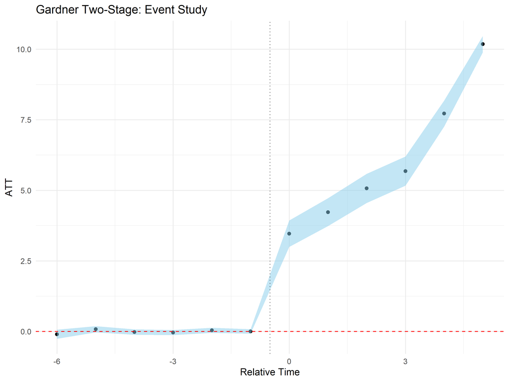

```r
did2s_es_coef <- broom::tidy(did2s_es, conf.int = TRUE) %>%
  filter(term != "Inf") %>%
  mutate(rel_time = as.numeric(gsub("rel_time::", "", term)))

ggplot(did2s_es_coef, aes(x = rel_time, y = estimate)) +
  geom_point() +
  geom_ribbon(aes(ymin = conf.low, ymax = conf.high), fill = "skyblue", alpha = 0.5) +
  geom_hline(yintercept = 0, linetype = "dashed", color = "red") +
  geom_vline(xintercept = -0.5, linetype = "dotted", alpha = 0.5) +
  labs(title = "Gardner Two-Stage: Event Study",
       x = "Relative Time", y = "ATT") +
  theme_minimal()
```

# 4. Results Comparison

## Summary Table

Comparison of ATT estimates across all methods.

```r
results <- tibble(
  Method = c("TWFE (biased)", "Callaway & Sant'Anna", "Sun & Abraham",
             "Wooldridge ETWFE", "Gardner Two-Stage"),
  ATT = c(coef(twfe)[1],
          cs_simple$overall.att,
          coef(sa_agg)[1],
          etwfe_agg$estimate,
          coef(did2s_static)[1]),
  SE = c(twfe_coef$std.error[1],
         cs_simple$overall.se,
         se(sa_agg)[1],
         etwfe_agg$std.error,
         coef_data$std.error[1])
) %>%
  mutate(
    CI_lower = ATT - 1.96 * SE,
    CI_upper = ATT + 1.96 * SE,
    Method = factor(Method, levels = c("Gardner Two-Stage", "Wooldridge ETWFE",
                                       "Sun & Abraham", "Callaway & Sant'Anna",
                                       "TWFE (biased)"))
  )

print(results, n = Inf)
```

```
# A tibble: 5 × 5
  Method                 ATT     SE CI_lower CI_upper
  <fct>                <dbl>  <dbl>    <dbl>    <dbl>
1 TWFE (biased)         4.36 0.242      3.89     4.84
2 Callaway & Sant'Anna  5.35 0.280      4.80     5.90
3 Sun & Abraham         5.35 0.0893     5.17     5.52
4 Wooldridge ETWFE      5.40 0.0620     5.27     5.52
5 Gardner Two-Stage     5.40 0.282      4.84     5.95
```

## Visual Comparison

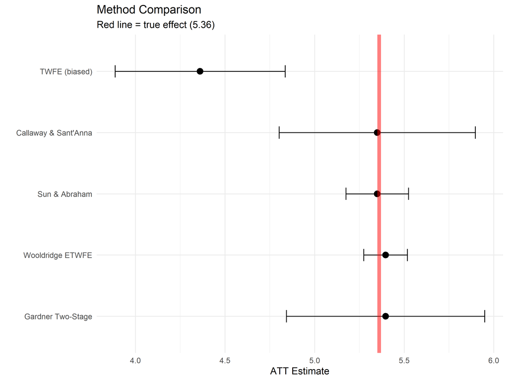

```r
ggplot(results, aes(x = Method, y = ATT)) +
  geom_point(size = 3) +
  geom_errorbar(aes(ymin = CI_lower, ymax = CI_upper), width = 0.2) +
  geom_hline(yintercept = 5.36, linetype = "solid", color = "red", alpha = 0.5, size = 2) +  # True effect
  coord_flip() +
  labs(title = "Method Comparison",
       subtitle = "Red line = true effect (5.36)",
       x = "", y = "ATT Estimate") +
  theme_minimal()
```

## Combined Event Study Plot

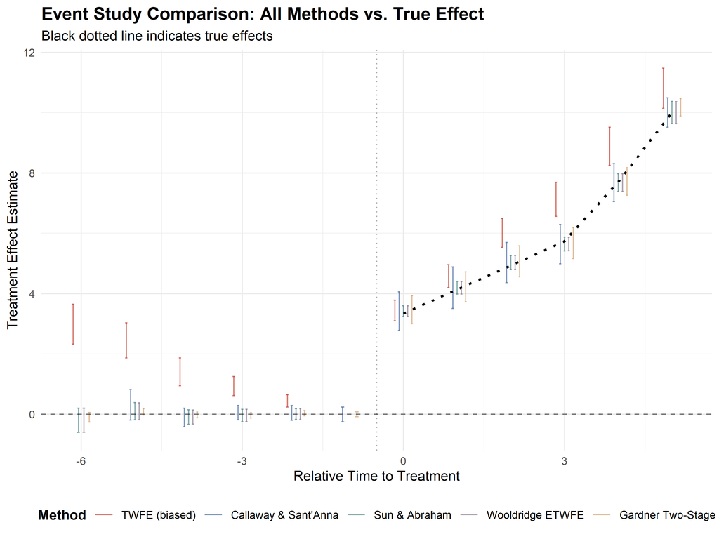

```r
## Combined Event Study Plot
# --- TRUE EFFECT LINE ---
true_es <- data %>%
  filter(treated == 1) %>%
  mutate(rel_time = time - treat_time) %>%
  group_by(rel_time) %>%
  summarise(true_effect = mean(true_te), .groups = "drop")

# --- Extract event study coefficients (same as before) ---

# 1. TWFE
twfe_es_df <- broom::tidy(twfe_es, conf.int = TRUE) %>%
  filter(term != "Inf") %>%
  mutate(
    rel_time = as.numeric(gsub("rel_time::", "", term)),
    method = "TWFE (biased)"
  ) %>%
  filter(!is.na(rel_time)) %>%
  select(method, rel_time, estimate, conf.low, conf.high)

# 2. Callaway & Sant'Anna
cs_es_df <- broom::tidy(cs_event, conf.int = TRUE) %>%
  mutate(
    rel_time = event.time,
    method = "Callaway & Sant'Anna"
  ) %>%
  select(method, rel_time, estimate, conf.low, conf.high)

# 3. Sun & Abraham
sa_es_df <- broom::tidy(sa, conf.int = TRUE) %>%
  filter(grepl("::", term)) %>%
  mutate(
    cohort = as.numeric(sub(".*treat_time = ([0-9]+)::.*", "\\1", term)),
    rel_time = as.numeric(sub(".*::", "", term)),
    method = "Sun & Abraham"
  ) %>%
  group_by(method, rel_time) %>%
  summarise(
    estimate = mean(estimate),
    conf.low = mean(conf.low),
    conf.high = mean(conf.high),
    .groups = "drop"
  )

# 4. Wooldridge ETWFE
etwfe_es_df <- as.data.frame(etwfe_es2) %>%
  mutate(
    rel_time = event,
    method = "Wooldridge ETWFE"
  ) %>%
  select(method, rel_time, estimate, conf.low, conf.high)

# 5. Gardner Two-Stage
did2s_es_df <- broom::tidy(did2s_es, conf.int = TRUE) %>%
  filter(term != "Inf") %>%
  mutate(
    rel_time = as.numeric(gsub("rel_time::", "", term)),
    method = "Gardner Two-Stage"
  ) %>%
  filter(!is.na(rel_time)) %>%
  select(method, rel_time, estimate, conf.low, conf.high)

# --- Combine all methods ---
all_es <- bind_rows(
  twfe_es_df,
  cs_es_df,
  sa_es_df,
  etwfe_es_df,
  did2s_es_df
) %>%
  mutate(
    method = factor(method, levels = c(
      "TWFE (biased)",
      "Callaway & Sant'Anna",
      "Sun & Abraham",
      "Wooldridge ETWFE",
      "Gardner Two-Stage"
    ))
  )

# --- Plot comparison with TRUE line ---
ggplot(all_es, aes(x = rel_time, y = estimate, color = method, shape = method)) +
  # geom_point(size = 2.5, position = position_dodge(width = 0.4)) +
  geom_errorbar(aes(ymin = conf.low, ymax = conf.high),
                width = 0.2,
                position = position_dodge(width = 0.4),
                alpha = 0.7) +
  # Add true effect line
  geom_line(data = true_es, aes(x = rel_time, y = true_effect),
            inherit.aes = FALSE, color = "black", linewidth = 1, linetype = "dotted") +
  geom_hline(yintercept = 0, linetype = "dashed", color = "black", alpha = 0.5) +
  geom_vline(xintercept = -0.5, linetype = "dotted", alpha = 0.3) +
  scale_color_manual(values = c(
    "TWFE (biased)" = "#C44536",
    "Callaway & Sant'Anna" = "#4A6FA5",
    "Sun & Abraham" = "#588B8B",
    "Wooldridge ETWFE" = "#8E7C93",
    "Gardner Two-Stage" = "#D4A574"
  )) +
    scale_shape_manual(values = c(
    "TWFE (biased)" = 16,
    "Callaway & Sant'Anna" = 17,
    "Sun & Abraham" = 15,
    "Wooldridge ETWFE" = 18,
    "Gardner Two-Stage" = 19
  )) +
  labs(
    title = "Event Study Comparison: All Methods vs. True Effect",
    subtitle = "Black dotted line indicates true effects",
    x = "Relative Time to Treatment",
    y = "Treatment Effect Estimate",
    color = "Method",
    shape = "Method"
  ) +
  theme_minimal() +
  theme(
    legend.position = "bottom",
    legend.title = element_text(face = "bold"),
    plot.title = element_text(face = "bold", size = 14)
  )
```

## Key Observations

Comparing the event study plots reveals:

1. **TWFE bias**: The TWFE estimates deviate substantially from the true ATT (5.36), particularly in post-treatment periods. This bias stems from forbidden comparisons between already-treated and newly-treated units.
2. **Pre-treatment trends**: Modern DiD methods show coefficients close to zero in pre-treatment periods, supporting the parallel trends assumption. TWFE may show spurious pre-trends due to misspecification.
3. **Dynamic effects**: All modern methods capture the growth in treatment effects over time (due to the 0.8 per-period accumulation in our DGP). TWFE fails to accurately represent this dynamic pattern.
4. **Convergence of modern methods**: Callaway & Sant’Anna, Sun & Abraham, Wooldridge ETWFE, and Gardner Two-Stage produce similar estimates that cluster around the true effect, demonstrating their robustness to treatment effect heterogeneity.
5. **Uncertainty**: Confidence intervals vary across methods, reflecting different estimation approaches and sample sizes used in comparisons. Methods using never-treated controls may have wider confidence intervals than those using not-yet-treated controls.